# What Factors Drive Personal Income?

## Section 2 - Model building

```
## Rows: 11,044
## Columns: 15
## $ location          <dbl> 1, 1, 2, 2, 1, 4, 4, 4, 5, 5, 5, 5, 5, 5, 1, 1, 1, 1…
## $ age               <dbl> 41, 58, 30, 48, 22, 25, 53, 35, 51, 26, 23, 28, 47, …
## $ race              <dbl> 1, 1, 1, 1, 2, 2, 1, 1, 1, 1, 1, 1, 1, 1, 1, 1, 2, 2…
## $ ethnic            <dbl> 24, 8, 11, 24, 1, 1, 14, 8, 24, 3, 14, 14, 18, 18, 8…
## $ degree            <dbl> 3, 1, 3, 4, 1, 0, 1, 1, 0, 0, 3, 3, 4, 1, 3, 1, 1, 0…
## $ prestige          <dbl> 69, 41, 72, 60, 26, 32, 29, 46, 50, 40, 63, 50, 63, …
## $ wrkslf            <dbl> 1, 2, 2, 2, 2, 2, 2, 2, 1, 2, 2, 1, 2, 2, 2, 1, 2, 2…
## $ income            <dbl> 10, 8, 9, 11, 11, 4, 11, 9, 12, 5, 10, 9, 10, 9, 11,…
## $ rincome           <dbl> 10, 7, 8, 11, 2, 4, 9, 4, 12, 5, 9, 9, 8, 6, 9, 9, 4…
## $ conrinc           <dbl> 59102, 25329, 30395, 75988, 6754, 15198, 42215, 1519…
## $ log_conrinc       <dbl> 10.987020, 10.139705, 10.322033, 11.238331, 8.817890…
## $ log_prestige      <dbl> 4.234107, 3.713572, 4.276666, 4.094345, 3.258097, 3.…
## $ Education         <chr> "Bachelor's", "High School", "Bachelor's", "Graduate…
## $ Higher_Education  <dbl> 1, 0, 1, 1, 0, 0, 0, 0, 0, 0, 1, 1, 1, 0, 1, 0, 0, 0…
## $ Higher_Education2 <chr> "Higher Education", "No Higher Education", "Higher E…
```

We will be using the training data to propose our models and make plots that allow us to explain why we are proposing our models and how we think different explanatory variables relate to our response variable. The test data will be used to validate the models we have created and show if they effectively explain the relationships in our data. To ensure our models will be as accurate as possible, we will be using the same seed number so our data is identical.

The response variable we will analyze is “conrinc”, which represents the inflation-adjusted income of the respondents in the GSS survey. The “conrinc” variable has a skewed distribution, so we have transformed it into “log_conrinc” since it produces a more normal distribution. On top of this, we have mutated the variables “Higher_Education”, “Higher_Education2”, and “Education” from the “degree” variable in our dataset to make our plots and models easier to understand and interpret.  
To start our evaluations, we will show a histogram that displays “log_conrinc” along with the number of observations and helpful statistics such as mean, median, Q1, and Q3. This allows us to see the range of “log_conrinc” and where our data peaks (around 10).

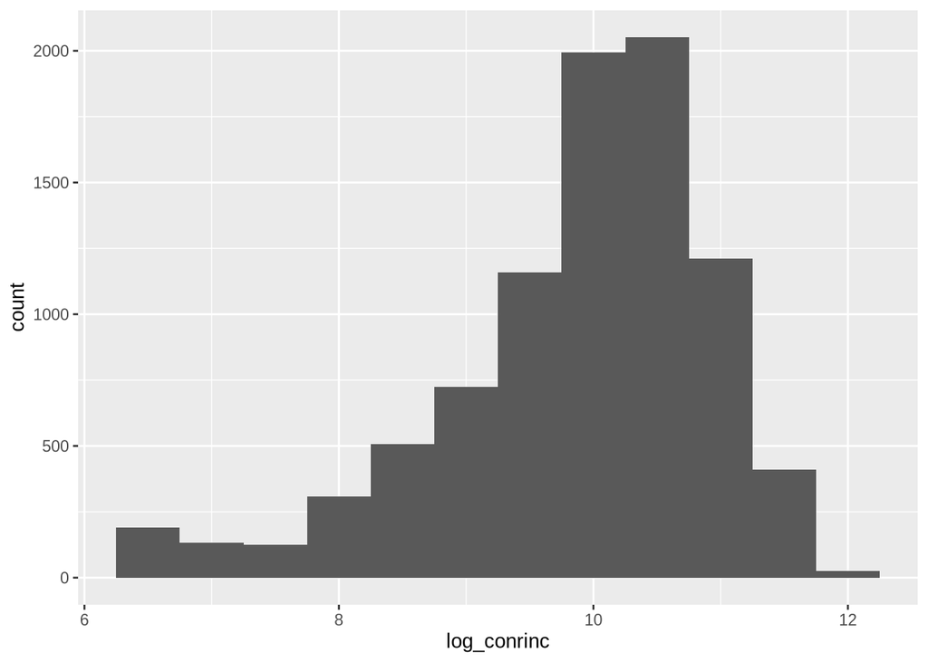

```
## # A tibble: 1 × 4
##   mean_income median_income    Q1    Q3
##         <dbl>         <dbl> <dbl> <dbl>
## 1        9.87          10.1  9.38  10.6
```

```
## # A tibble: 1 × 2
##   lower upper
##   <dbl> <dbl>
## 1 0.527 0.617
```

Since it’s been shown that there may be a relationship between education level and income, we have constructed a box plot to show this relationship. Along with the plot, the mean, median, quartile 1, and quartile 3 incomes are displayed and sorted by level of education. This type of plot if very helpful for visualizing and comparing categorical data and identifying outliers.

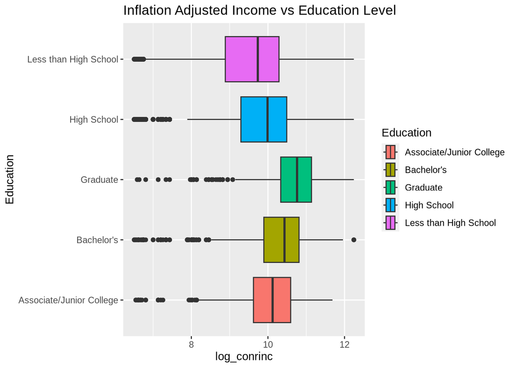

```
## # A tibble: 5 × 5
##   Education                mean_income median_income    Q1    Q3
##   <chr>                          <dbl>         <dbl> <dbl> <dbl>
## 1 Graduate                       10.6          10.8  10.3   11.1
## 2 Bachelor's                     10.2          10.4   9.89  10.8
## 3 Associate/Junior College        9.95         10.1   9.62  10.6
## 4 High School                     9.78          9.99  9.29  10.5
## 5 Less than High School           9.51          9.74  8.89  10.3
```

In order to visualize the numerical explanatory variable “prestige” and its relationship to “log_conrinc”, we will be using a scatterplot. Before looking at the graph and statistics, I would assume that there will be a positive correlation between these variables since more prestigious jobs are normally much more difficult to get and tend to pay more for this reason.

As expected, the plot has an R value of 0.33, which shows a weak to moderate positive relationship between inflation-adjusted income and prestige. The mean and median income displayed for each prestige value shows that lower prestiges, such as 74, can have an average higher income (11.44) than higher prestiges like 82, which has a mean income value of 11.06. Despite this occasionally happening in our data, the income value still tends to increase as prestige does.

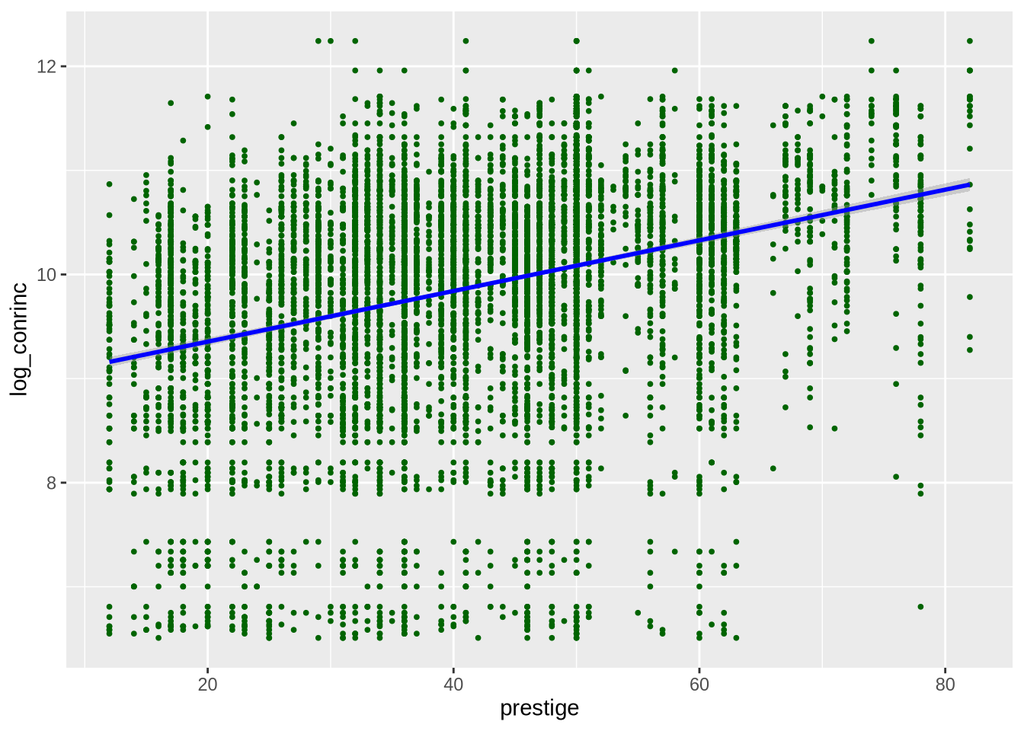

```
## # A tibble: 60 × 6
##    prestige mean_income median_income    Q1    Q3 sd_income
##       <dbl>       <dbl>         <dbl> <dbl> <dbl>     <dbl>
##  1       82        11.1          11.5 10.4   11.7     0.849
##  2       78        10.4          10.6 10.1   10.9     0.927
##  3       76        11.0          11.3 10.7   11.6     0.744
##  4       74        11.4          11.5 11.2   11.6     0.381
##  5       72        10.6          10.6 10.2   11.1     0.583
##  6       71        10.6          10.8 10.3   10.9     0.640
##  7       70        10.9          10.8 10.7   11.0     0.457
##  8       69        10.5          10.7  9.82  11.1     0.774
##  9       68        10.9          11.0 10.7   11.1     0.417
## 10       67        10.8          10.9 10.6   11.2     0.686
## # ℹ 50 more rows
```

```
## # A tibble: 1 × 1
##       R
##   <dbl>
## 1 0.326
```

```
##
## Call:
## lm(formula = log_conrinc ~ age, data = clean_support_model)
##
## Residuals:
##      Min       1Q   Median       3Q      Max
## -0.19631 -0.01862  0.01284  0.03251  0.10389
##
## Coefficients:
##             Estimate Std. Error t value Pr(>|t|)
## (Intercept) 0.894283   0.005579  160.29   <2e-16 ***
## age         0.061998   0.003534   17.55   <2e-16 ***
## ---
## Signif. codes:  0 '***' 0.001 '**' 0.01 '*' 0.05 '.' 0.1 ' ' 1
##
## Residual standard error: 0.04932 on 8833 degrees of freedom
## Multiple R-squared:  0.03367,    Adjusted R-squared:  0.03357
## F-statistic: 307.8 on 1 and 8833 DF,  p-value: < 2.2e-16
```

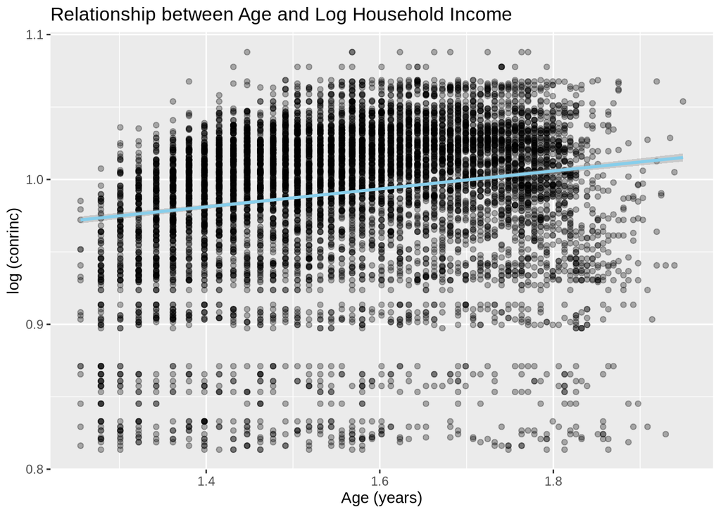

In this simple regression model, I explored how a respondent’s income (conrinc) is related to their age. Since income tends to be highly skewed, I applied a log10 transformation to conrinc, which helps normalize the distribution.